# National Parks Analysis

By: Sofia Hirschmann

21 May 2021

# **National Parks**

```r
library(tidyverse)
library(ggridges)
library(tidymodels)
```

The national parks in the US have served as incredible attractions over the years. They are a great way to get outdoors and experience nature for what it is which I can only assume has earned an even greater appreciation after this past year of on and off quarantines. The dataset *park_visits* posted on the Tidy Tuesday website in 2019 provides a surplus of data on parks over the years.

## **Question**

This dataset contains a large amount of variables but the one’s that I focus on most are *region*, *unit_type* (type of park), *year*, and *visitors* (the total visitors recorder each year). The reason why these are the variables that I chose to focus on is because I want to investigate whether the type of park along with year can be used to preredict vistor count.

- To do so I explore trends through graphics as well as produce a predictive model

## **Step 1:** Determine top ten park types

Since the dataset is so large I chose to focus on the park types that are in the top ten most visited over the years in the country as well as in the Northeast. - I used *arrange(desc(visitors))* to organize the data by most visited - I then used *head(data, 10)* to isolate the top ten of each group

```r
parks_totalNE = park_visits %>%
  #choose the variables of interest
  select(year, region, state, unit_name, unit_type, visitors) %>%
  #cut dataset down to total visitor count over the years as well as just parks in the NE
  filter(year == "Total", region == "NE") %>%
  #arrange data from highest visitor count to lowest
  arrange(desc(visitors))


parks_totals = park_visits %>%
  #choose the variables of interest
  select(year, region, state, unit_name, unit_type, visitors) %>%
  #cut dataset down to total visitor count over the years
  filter(year == "Total") %>%
  #arrange data from highest visitor count to lowest
  arrange(desc(visitors))
```

```r
#head function paired with 10 pulls the first ten rows in each data set
head(parks_totalNE, 10)
```

```
## # A tibble: 10 x 6
##    year  region state unit_name                      unit_type          visitors
##    <chr> <chr>  <chr> <chr>                          <chr>                 <dbl>
##  1 Total NE     NY    Gateway National Recreation A… National Recreati…   3.30e8
##  2 Total NE     VA    Colonial National Historical … National Historic…   2.82e8
##  3 Total NE     MA    Cape Cod National Seashore     National Seashore    2.36e8
##  4 Total NE     PA    Independence National Histori… National Historic…   1.94e8
##  5 Total NE     ME    Acadia National Park           National Park        1.64e8
##  6 Total NE     NY    Statue Of Liberty National Mo… National Monument    1.62e8
##  7 Total NE     PA    Delaware Water Gap National R… National Recreati…   1.61e8
##  8 Total NE     PA    Gettysburg National Military … National Military…   1.30e8
##  9 Total NE     VA    Shenandoah National Park       National Park        1.26e8
## 10 Total NE     NY    Castle Clinton National Monum… National Monument    1.13e8
```

```r
head(parks_totals, 10)
```

```
## # A tibble: 10 x 6
##    year  region state unit_name                    unit_type            visitors
##    <chr> <chr>  <chr> <chr>                        <chr>                   <dbl>
##  1 Total NT     NC    Blue Ridge Parkway           Parkway                8.72e8
##  2 Total PW     CA    Golden Gate National Recrea… National Recreation…   6.11e8
##  3 Total SE     NC    Great Smoky Mountains Natio… National Park          5.22e8
##  4 Total SE     MS    Natchez Trace Parkway        Parkway                4.43e8
##  5 Total PW     NV    Lake Mead National Recreati… National Recreation…   4.12e8
##  6 Total NC     VA    George Washington Memorial … National Parkway       3.30e8
##  7 Total NE     NY    Gateway National Recreation… National Recreation…   3.30e8
##  8 Total NE     VA    Colonial National Historica… National Historical…   2.82e8
##  9 Total NC     DC    Lincoln Memorial             National Memorial      2.39e8
## 10 Total NC     DC    National Capital Parks       Park                   2.36e8
```

From this we learn that the parks types that are present in the top ten of the country are “Parkway”, “National Recreation Area”, “National Park”, “National Historical Park”, “National Memorial”, “Park”, “National Parkway” and the park types present in the top ten of the NE are “National Recreation Area”, “National Park”, “National Historical Park”, “National Military Park”, “National Seashore”, “National Monument”.

## **Step 2**: Look at the distribution of yearly visits in top 6 park types in the NE

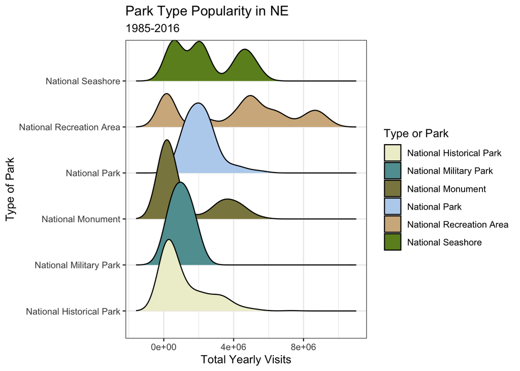

```r
NE_parks = park_visits %>%
  #choose the variables of interest
   select(year, region, state, unit_name, unit_type, visitors) %>%
  #cut dataset down to the top six park types in the NE after 1985
  filter(unit_type %in% c("National Recreation Area", "National Park", "National Historical Park", "National Military Park", "National Seashore", "National Monument") & year != "Total" & region == "NE" & year >= 1985)

#create density plot with the x being visitor counts and the y being the type of park
ggplot(data = NE_parks, aes(x = visitors, y = unit_type, fill = unit_type)) +
  geom_density_ridges() +
  theme_ridges() +
  theme_bw()+
  #set your own colors
  scale_fill_manual(values = c("lightyellow2", "cadetblue", "khaki4", "slategray2", "tan", "olivedrab"))+
  #adjust labels to explain visual better
  labs(x = "Total Yearly Visits", y = "Type of Park",
       title = "Park Type Popularity in NE", subtitle = "1985-2016", fill = "Type or Park")
```

This visual shows that, for the most part, each park type has pretty similar ranges of visitor counts over the years in the NE. The National Recreation Area and Seashore have their counts a little more spread out, potentially because they are more popular or they just have more space to take in more people every day.

## **Step 3**: Look at mean visits each year for each park type

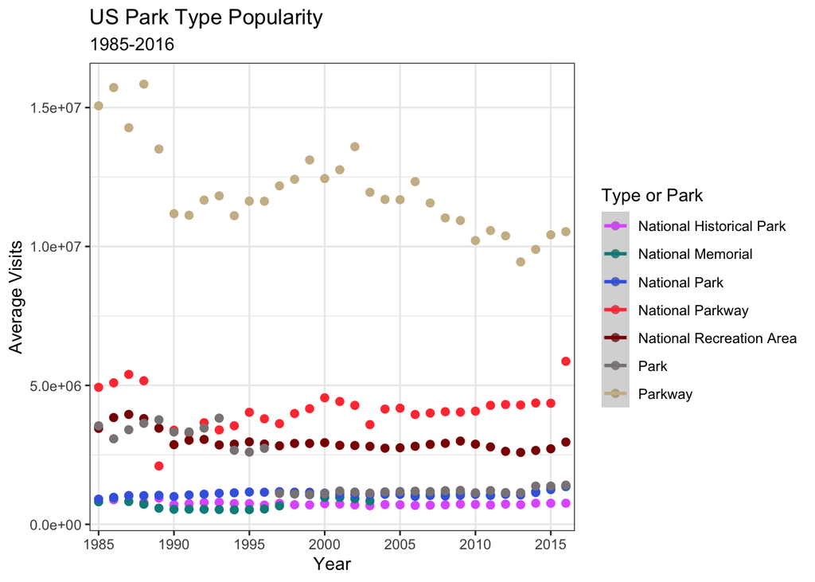

```r
visitor_means = park_visits %>%
   #choose the variables of interest
   select(year, region, state, unit_name, unit_type, visitors) %>%
  #cut dataset down to the top seven park types after 1985
  filter(unit_type %in% c("Parkway", "National Recreation Area", "National Park", "National Historical Park", "National Memorial", "Park", "National Parkway") &  year != "Total" & year >= 1985) %>%
  #compress dataset to be organized by park type and by year
  group_by(year, unit_type) %>%
  #generate means of each park type in each year
    summarise(mean_visit = mean(visitors))
#create scatterplot with the x being year, the y being the mean visit value each year, park type seperated by color
ggplot(data = visitor_means, aes(x = year, y = mean_visit, color = unit_type)) +
  geom_point(size = 2) +
  #break up years in x axis by 5 so it doesn't get cluttered
  scale_x_discrete(breaks = seq(1985, 2016, by = 5)) +
  #assign colors
  scale_colour_manual(values = c("mediumorchid1", "cyan4", "royalblue", "brown1", "red4", "lavenderblush4", "wheat3")) +
  theme_bw()+
  geom_smooth(method = "lm") +
  #adjust labels
  labs(x = "Year", y = "Average Visits",
       title = "US Park Type Popularity", subtitle = "1985-2016", color = "Type or Park")
```

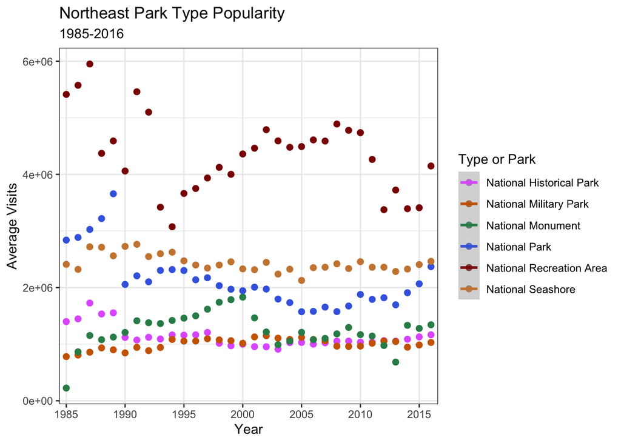

```r
visitor_meansNE = park_visits %>%
   #choose the variables that I am interested in
   select(year, region, state, unit_name, unit_type, visitors) %>%
    #cut dataset down to the top six park types after 1985 in just the NE region
  filter(unit_type %in% c("National Recreation Area", "National Park", "National Historical Park", "National Military Park", "National Seashore", "National Monument") & year != "Total" & region == "NE" & year >= 1985) %>%
  #compress dataset to be organized by park type and by year
  group_by(year, unit_type) %>%
  #generate means of each park type in each year
    summarise(mean_visit = mean(visitors))
#create scatterplot with the x being year, the y being the mean visit value each year, park type seperated by color
ggplot(data = visitor_meansNE, aes(x = year, y = mean_visit, color = unit_type)) +
  geom_point(size = 2) +
  #break up years in x axis by 5 so it doesn't get cluttered
  scale_x_discrete(breaks = seq(1985, 2016, by = 5)) +
  #assign colors
  scale_colour_manual(values = c("mediumorchid1", "darkorange3", "seagreen", "royalblue", "red4", "peru"))+
  theme_bw()+
  geom_smooth(method = "lm") +
  #adjust labels
  labs(x = "Year", y = "Average Visits",
       title = "Northeast Park Type Popularity", subtitle = "1985-2016", color = "Type or Park")
```

Looking at these two graphics, one could assume predictability by looking at the park type distributions in the whole country over the last 35 years because each park type generally stays around the same range. However, what I did find interesting is that Parkways across the country reflects trends very similar to those seen in National Recreation Areas in the Northeast, both dip significantly in visitor counts around 1990 so I would be curious to explore whether or not that occurs anywhere else in this dataset and if so why.

## **Step 4**: Create a predictive model

```r
park_years = park_visits %>%
   #choose the variables of interest
  select(year, region, state, unit_name, unit_type, visitors) %>%
  #cuts out when year = Total in the dataset
  filter(year != "Total")

set.seed(21)

parks_split = initial_split(park_years, prop = 0.7)

parks_split
```

```
## <Analysis/Assess/Total>
## <14822/6352/21174>
```

```r
#data used to build the model
parks_train = training(parks_split)
#data that the model has never seen before
parks_test = testing(parks_split)

dim(parks_train)
```

```
## [1] 14822     6
```

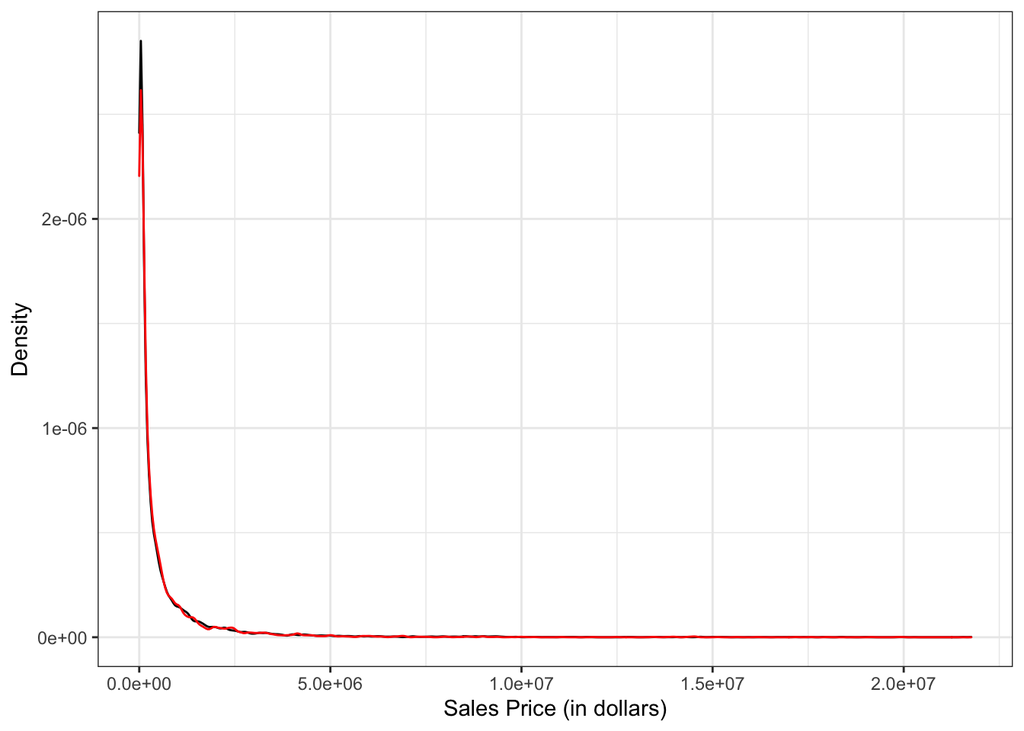

```r
#use to check that the target (visitors) is similar between the training and testing, density plots.
ggplot() +
  geom_density(data = parks_train, aes(x = visitors)) +
  geom_density(data = parks_test, aes(x = visitors), color = "red") +
  labs(x = "Sales Price (in dollars)", y = "Density") +
  theme_bw()
```

```r
#builds/specifies a model, fits linear model to datset after data splitting
lm_fit_train =
  linear_reg() %>%
  set_engine(engine = "lm") %>%
  fit(visitors ~ unit_type + year, data = parks_train)

#use the linear regression model, it takes all observed x values and plugs them into the equation for the x value, generate prediction on testing set
lm_pred_test = lm_fit_train %>%
  predict(new_data = parks_test)

dim(lm_pred_test)
```

```
## [1] 6352    1
```

```r
#get prediction metric
parks_test %>%
  select(year, visitors) %>%
  mutate(visitors_Pred = lm_pred_test$.pred) %>%
  rmse(truth = visitors, estimate = visitors_Pred)
```

```
## # A tibble: 1 x 3
##   .metric .estimator .estimate
##   <chr>   <chr>          <dbl>
## 1 rmse    standard    1101742.
```

With the rmse of 1101742 from this predictive model along with the graphics created earlier, it is fair to say that visitor count can be predicted for a lot of park types because the majority remain in a fairly standard range of visitors throughout the years, however there are a few park types that vary over the years like National Recreation Areas in NE and Parkways in the US that vary in unpredictable ways so we can not make the general statement that visitor counts can be predicted by year and park type.